# Scenario 3: CKMR simulation results: No biennial female breeders

```
## Of the 5760 parameter estimates from these simulations, 0 instances failed to converge at Rhat > 1.01
```

## Background info

One hundred different populations were simulated where 0% of females in the population bred biennially. All females had an equal chance of breeding each year.

Each population was sampled at four different sampling intensities corresponding to 0.5, 1, 1.5, and 2 percent of the juvenile population each year over four consecutive years of sampling. Samples were either targeted to the young-of-year (YOY) portion of the population only, or included juveniles of all age classes. A pairwise comparisons matrix that included all possible positive and negative comparisons was used as input to a CKMR model that either a) assumed no prior information for breeding schedule (psi) *or* survival (phi), or b) assumed the breeding schedule was known without error (i.e. fixed to the truth) *and* included a tight prior on survival dnorm(mean = truth, sd = 0.02).

## Figure 1: Accuracy of abundance estimates depends on sampling scheme and prior demographic information

**Sampling scheme:** Red and blue reflect sampling schemes that target YOY only; green and purple reflect sampling schemes where the entire juvenile population (ages 0-11) were available for sampling.  
**Prior information:** Red and green results come from a model that assumed no prior information for psi or survival; blue and purpose results come from a model that assumed psi was known without error and gave a tight prior to survival.  
**Main takeaways:** This figure shows results for the lowest and highest sample schemes employed only (i.e. 0.5% and 2% of the juvenile population). Here, we see that the model performs ppretty well for females, and great for males. The reason the female results are not as great is likely because I mistakenly used the number of breeders as the truth, when it should have been the total females. Setting the true value as the total number of females should make the results more accurate.

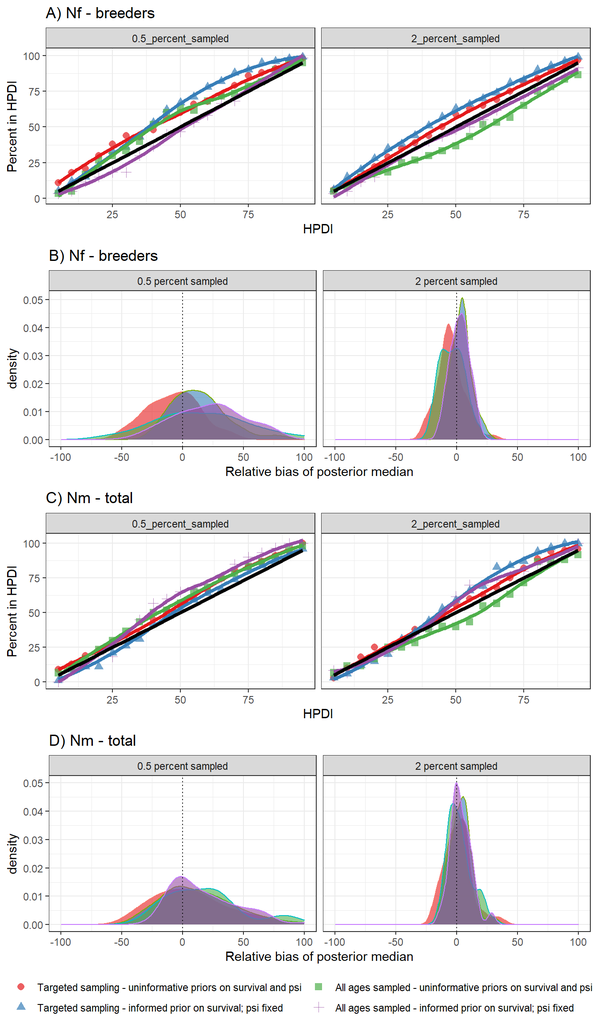

## Figure 2: Accuracy of survival estimates depends on sampling scheme and prior demographic information

**Sampling scheme:** Red and blue reflect sampling schemes that target YOY only; green and purple reflect sampling schemes where the entire juvenile population (ages 0-11) were available for sampling.  
**Prior information:** Red and green results come from a model that assumed no prior information for psi or survival (diffuse priors); blue and purpose results come from a model that assumed psi was known without error and gave a tight prior to survival.  
**Main takeaways:** When priors are diffuse (red and green), survival estimates are all over the place. This is likely because the model reallllly struggled to estimate psi, which was fixed to 0 in the simulation.

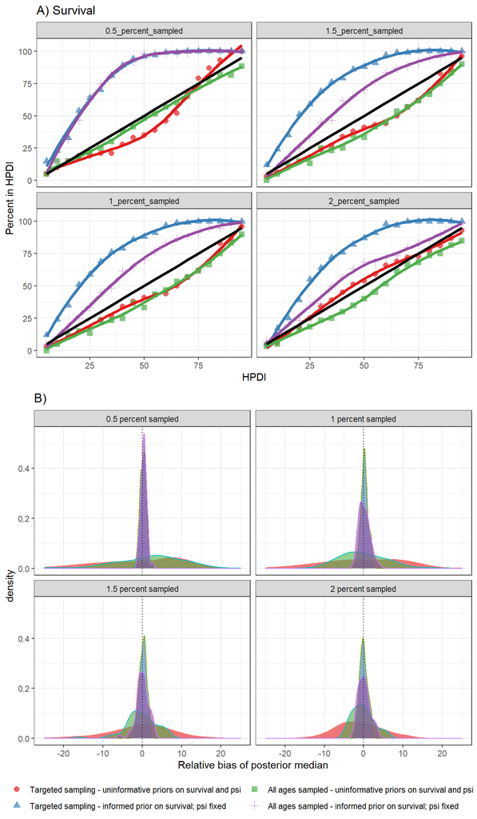

**A and B:** In this scenario, where all animals breed annually, we see a slight increase in the number of HSPs detected when sampling is focused on YOY vs all age classes. This is distinctly different than when females breed biennially. **C and D:** Relative bias of abundance estimate by the percent difference between observed and expected HSPs. Here, we see that we are consistently detecting more HSPs than expected for females. This likely indicates that there is an issue calculating the expected values of HSPs, and I would bet that it’s because I’ve included psi in the calculations of expectations.

**Main takeaways:** When breeding is annual, targeted sampling of YOY results in more HSPs than sampling across age classes. This is distinctly different than the scenario where females breed biennially, which showed the opposite trend.  
In addition, it appears my calculations of expected HSPs is wrong, likely because I included psi in this situation where the true psi should be 0 (or near there).

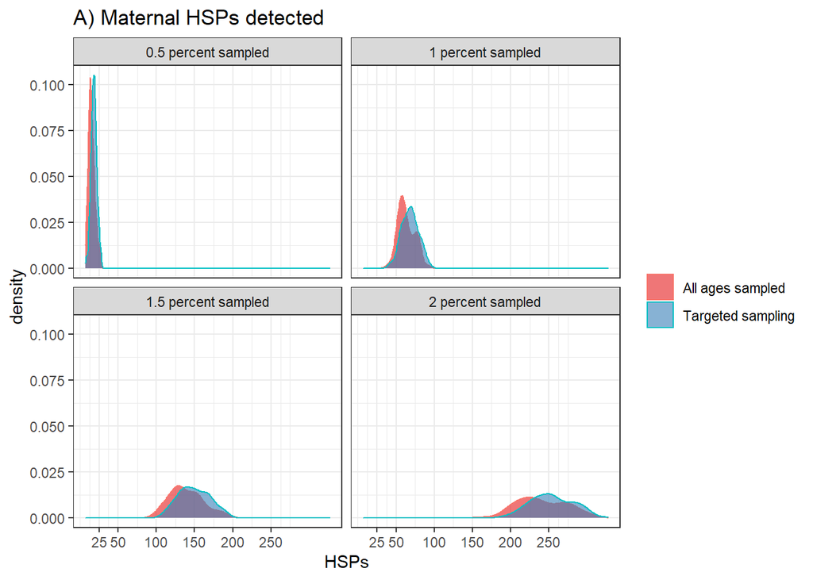

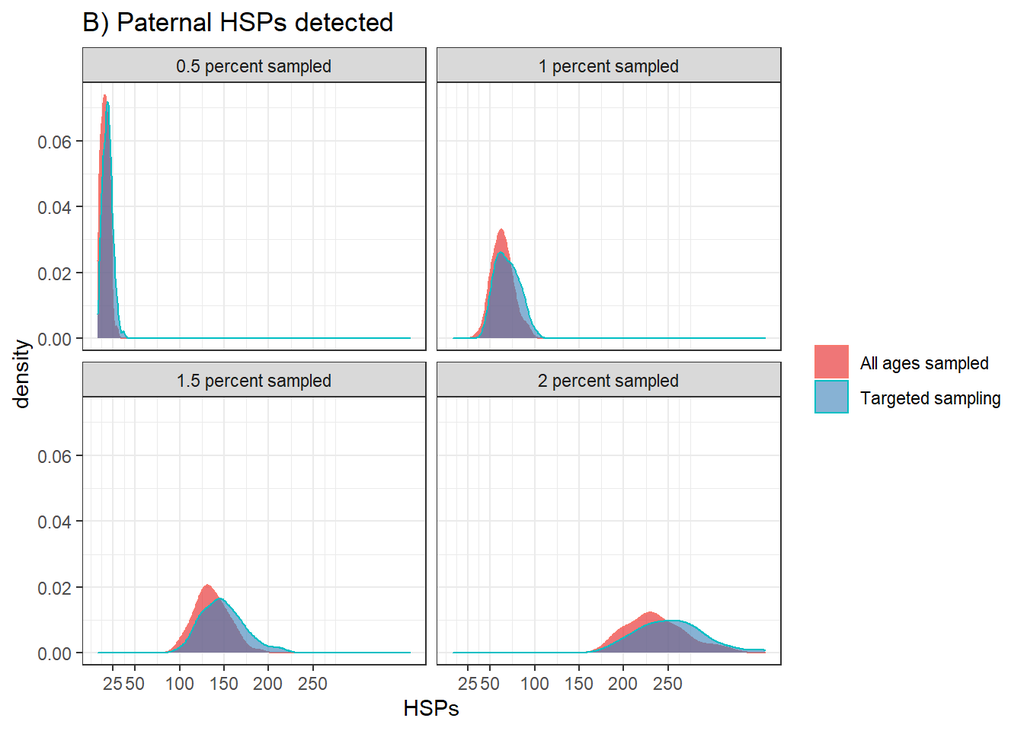

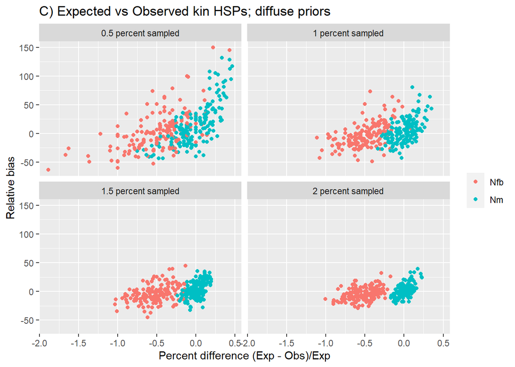

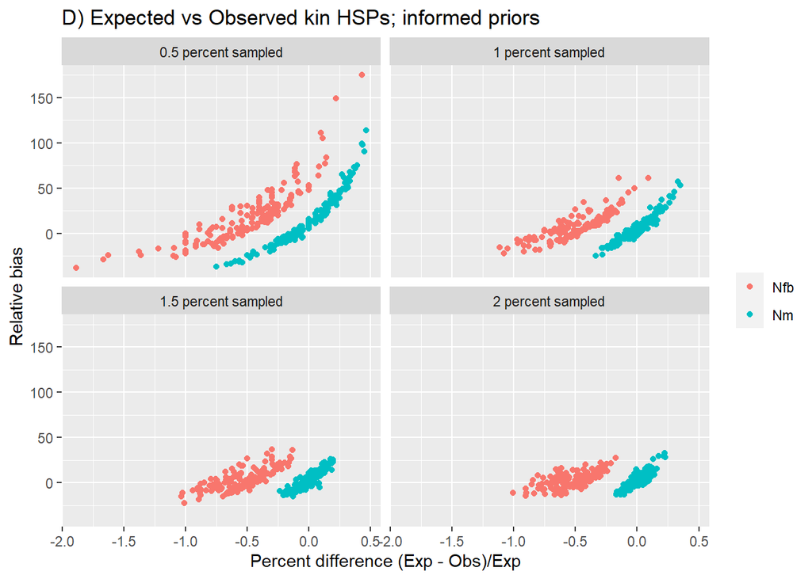